# Computer lab 3: Solutions

Richard Wilkinson

## Question 1

We will replicate the linear regression and regularized linear least squares examples from this week, with a different model. First, we will generate a noisy dataset of 200 samples coming from
$$v_i=u_i^2+\mathcal{N}(0,0.04)\,,\quad i=1,\ldots,200\,,$$
where the $u_i$’s are uniformly sampled in $[-1,1]$, and $\mathcal{N}(0,0.04)$ means adding Gaussian noise of mean 0 and variance $0.04$ for each sample.

- Generate the pairs $(u_i,v_i)$ using suitable random generators. Make a plot illustrating $(u_i,v_i)$. What is the model you can identify to express $v$ as a function of $u$?

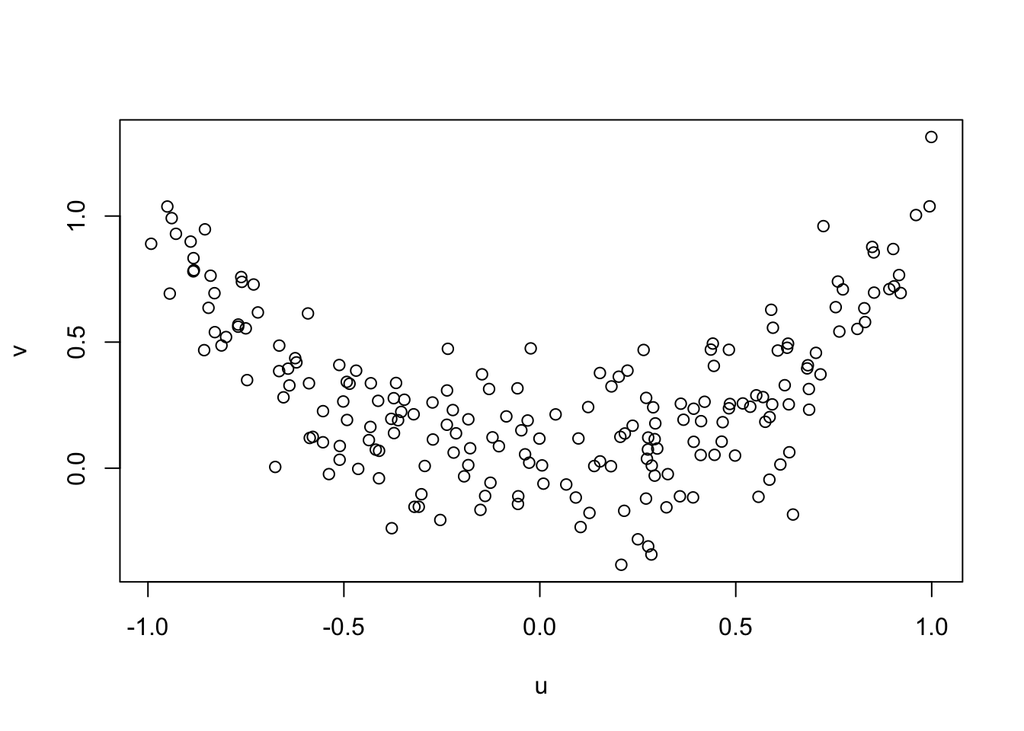

```r
u <- sort(runif(200, -1,1)) # ordered so that the regularization makes sense
v <- u^2 + rnorm(200,0, sd=sqrt(0.04))
plot(u,v)
```

The plot clearly suggests a quadratic relationship between v and u.

- Describe the least-squares regression problem for finding the optimal parameters in the model
  $$v(u)=au^2+bu+c$$

We can write the linear regression model $v_i=a+bu_i+cu_i^2+\epsilon$ as
$$\mathbf{v}= \mathbf{A}\beta+\epsilon$$
where $\beta=(a, b,c)^\top$. If we have $n$ samples, then
$$\mathbf{A}=\begin{pmatrix}1 & u_1 & u_1^2\\
\vdots\\
1 & u_n & u_n^2\end{pmatrix}
\in\mathbb{R}^{n\times 3}\qquad \mathbf{v}=\begin{pmatrix}v_1\\\vdots\\ v_n \end{pmatrix}\in\mathbb{R}^{n}\mbox{ etc.}$$

- Compute the least squares solution and compute the total least squares error in the $\ell_2$ norm.

We can form the normal equations
$$\mathbf{A}^\top \mathbf{A}\beta = \mathbf{A}^\top \mathbf{v}$$
which we can solve as follows

```r
A <- cbind(rep(1,200), u, u^2)
(betahat <- solve(t(A)%*%A, t(A)%*%v))
```

```
##           [,1]
##    0.008917681
## u -0.006893754
##    0.947807248
```

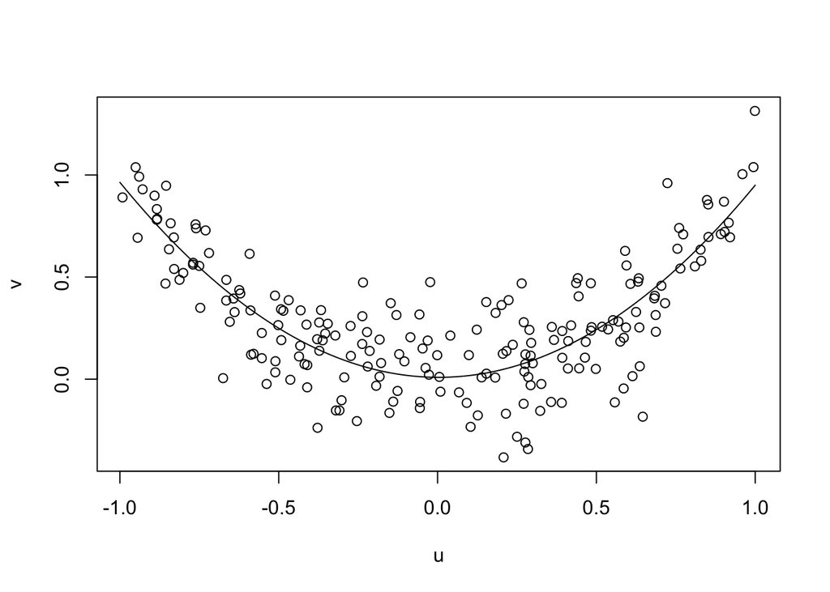

```r
totalss <- t(A%*%betahat-v)%*%(A%*%betahat-v)
plot(u,v)
u.plt<-seq(-1,1,0.01)
lines(u.plt, cbind(rep(1, length(u.plt)), u.plt, u.plt^2)%*%betahat)
```

R has (of course), built in functions for solving least squares problems:

```r
(fit<-lm(v~1+u+I(u^2)))
```

```
##
## Call:
## lm(formula = v ~ 1 + u + I(u^2))
##
## Coefficients:
## (Intercept)            u       I(u^2)
##    0.008918    -0.006894     0.947807
```

- Now, instead of solving a regression problem, use the $v_i$ values to recover a denoised signal using regularized least squares using the same total variation regularization described in the lecture notes

```
We assemble the regularization matrix $\mathbf{L}$ from  the notes
```

```r
L <- matrix(0, nr=200-1,nc=200)
for(i in 1:(199)){
  L[i,i]=1
  L[i,i+1]=-1
}
```

We set the regularization parameter $\lambda=100$ ( try different values to see the effect of different regularization values) and solve the regularized least squares solution

```r
lambda=100
vrecon<-solve(diag(200)+lambda * t(L)%*%L, v)
```

and we plot the regularized signal against the noisy measurements

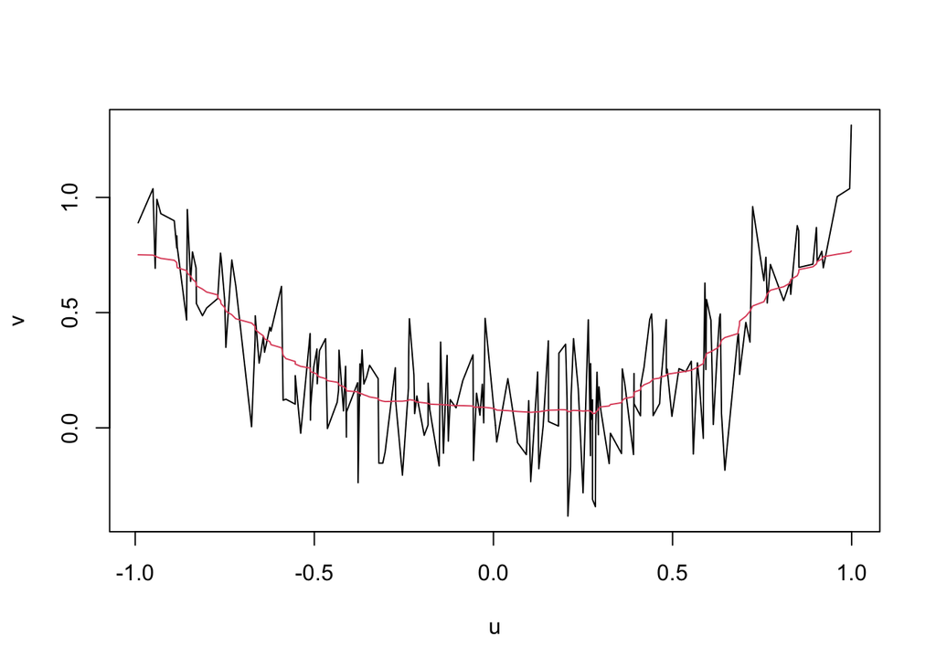

```r
plot(u,v, type='l')
points(u,vrecon, type='l', col=2)
```

## Question 2

Consider the linear systems
$$\begin{align}
x+y&=2\\
x+1.001y &=2\nonumber
\end{align}$$
and
$$\begin{align}
x+y&=2\\
x+1.001y &=2.001\nonumber
\end{align}$$

- Find the solution of both systems. Check your answer by using the `solve` command in R.

Note that a small change in the RHS ($\mathbf{b}$ in the terminology of the notes) has led to a large change in the solutions ($\mathbf{x}$).

```r
A <-matrix(c(1,1,1, 1.001), nr=2, byrow=T)
solve(A, c(2,2))
```

```
## [1] 2 0
```

```r
solve(A, c(2, 2.001))
```

```
## [1] 1 1
```

- We can measure the sensitivity of the linear system
  $$\mathbf{A}\mathbf{x}=\mathbf{b}$$
  (where $\mathbf{A}$ is a positive definite $n \times n$ matrix) by measuring how much the output $\mathbf{x}$ changes as $\mathbf{b}$ changes. Suppose $\mathbf{b}$ changes to $\mathbf{b}+\delta\mathbf{b}$, and that this results in the solution $\mathbf{x}$ changing to $\tilde{\mathbf{x}}=\mathbf{x}+\delta\mathbf{x}$. Show that the relative change in $\mathbf{x}$ compared to the relative change to $\mathbf{b}$ can be expressed as follows:
  $$\frac{\| \delta \mathbf{x}\| /\|\mathbf{x}\|}{\| \delta\mathbf{b}\| /\|\mathbf{b}\|} = \frac{\| \mathbf{A}^{-1} \delta \mathbf{b}\|}{||\delta \mathbf{b}||}\frac{||\mathbf{A}\mathbf{x}||}{||\mathbf{x}||}$$
  ***

Note that $\mathbf{A}\mathbf{x}=\mathbf{b}$ and $\mathbf{A}(\mathbf{x}+\delta\mathbf{x})=\mathbf{b}+\delta\mathbf{b}$ thus $\mathbf{A}\delta\mathbf{x}=\delta\mathbf{b}$. Thus we see
$$\frac{\| \delta \mathbf{x}\| /\|\mathbf{x}\|}{\| \delta\mathbf{b}\| /\|\mathbf{b}\|} = \frac{\| \mathbf{A}^{-1} \delta \mathbf{b}\|}{||\delta \mathbf{b}||}\frac{||\mathbf{A}\mathbf{x}||}{||\mathbf{x}||}.$$

- Thus show that for the $L_2$ norm, we have
  $$\max_{\mathbf{b}, \delta \mathbf{b}} \frac{\| \delta \mathbf{x}\| /\|\mathbf{x}\|}{\| \delta\mathbf{b}\| /\|\mathbf{b}\|} = \frac{\lambda_{max}(\mathbf{A})}{\lambda_{min}(\mathbf{A})}$$
  where $\lambda_{max}(\mathbf{A})$ and $\lambda_{min}(\mathbf{A})$ are the largest and smallest eigenvalues of $\mathbf{A}$.

Recall the definition of the matrix norm induced by the $L_2$ norm, and first show that
$$\max_{\mathbf{b}, \delta \mathbf{b}} \frac{\| \delta \mathbf{x}\| /\|\mathbf{x}\|}{\| \delta\mathbf{b}\| /\|\mathbf{b}\|} = ||\mathbf{A}^{-1}||\cdot ||\mathbf{A}||.$$

Recall that for the induced 2-norm for matrices

$$||\mathbf{A}||_2 = \max \{||\mathbf{A}\mathbf{x}||_2 : ||\mathbf{x}||\leq 1 \}=\max_{\mathbf{x}\not =0} \frac{||\mathbf{A}\mathbf{x}||_2}{||\mathbf{x}||_2}$$

Thus we can see that

$$\max_{\mathbf{b}, \delta \mathbf{b}} \frac{\| \delta \mathbf{x}\| /\|\mathbf{x}\|}{\| \delta\mathbf{b}\| /\|\mathbf{b}\|} = \max_{\delta\mathbf{b}}\frac{\| \mathbf{A}^{-1} \delta \mathbf{b}\|}{||\delta \mathbf{b}||}\max_{\mathbf{x}}\frac{||\mathbf{A}\mathbf{x}||}{||\mathbf{x}||} = ||\mathbf{A}^{-1}||. ||\mathbf{A}||.$$

Recall that $||\mathbf{A}||_2 = \lambda_{max}(\mathbf{A})$, and that the eigenvalues of $\mathbf{A}^{-1}$ are $1/\lambda_i(\mathbf{A})$ so that $||\mathbf{A}^{-1}||=\frac{1}{\lambda_{min}(\mathbf{A})}$. The result then follows.

This is known as the condition number of $\mathbf{A}$. Compute $\mathbf{A}$ for the linear systems above.

```r
eigs <- eigen(A)$values
eigs[1]/eigs[2]
```

```
## [1] 4002.001
```

```r
kappa(A, exact=T) # built in function in R
```

```
## [1] 4002.001
```